# On the teaching of ecological restoration in Brazil: an analysis of postgraduate courses - Sansevero - 2018 - Restoration Ecology - Wiley Online Library

[Restoration Ecology](https://onlinelibrary.wiley.com/journal/1526100x)

[Volume 26, Issue 5](https://onlinelibrary.wiley.com/toc/1526100x/2018/26/5) p. 997-1004

[figure not shown]

RESEARCH ARTICLE

Full Access

# On the teaching of ecological restoration in Brazil: an analysis of postgraduate courses

[Jerônimo B. B. Sansevero](https://onlinelibrary.wiley.com/action/doSearch?ContribAuthorRaw=Sansevero%2C+Jer%C3%B4nimo+B+B),

Address correspondence to J. B. B. Sansevero, email

[Jorge M. Alonso](https://onlinelibrary.wiley.com/action/doSearch?ContribAuthorRaw=Alonso%2C+Jorge+M),

[Micael C. Booth](https://onlinelibrary.wiley.com/action/doSearch?ContribAuthorRaw=Booth%2C+Micael+C),

[Mateus M. Bueno](https://onlinelibrary.wiley.com/action/doSearch?ContribAuthorRaw=Bueno%2C+Mateus+M),

[Lucas S. Carvalho](https://onlinelibrary.wiley.com/action/doSearch?ContribAuthorRaw=Carvalho%2C+Lucas+S),

… See all authors

First published: 25 December 2017

https://doi.org/10.1111/rec.12662

Citations: 9

Author contributions: JBBS, RV conceived and designed the research; JMA, MCB, MMB, LSC, NC, MDSF, FAM collected data on the postgraduate courses; JBBS, MCB analyzed the data; JBBS, JMA, LSC, RV wrote the manuscript.

*Coordinating Editor: Cara Nelson*

## Abstract

Several ambitious restoration targets have been set for recovering degraded ecosystems in Brazil (21 million hectares with a legal deficit of native vegetation). The development of scientific knowledge and skilled professionals is necessary to meet this demand and is fundamental for achieving success in medium- and long-term restoration. In this study, we describe the availability and profile of postgraduate courses on ecological restoration in Brazil. We surveyed 272 postgraduate programs, comprising six specific areas of concentration (forestry, soil sciences, botany, environmental engineering, ecology, and environmental science). We analyzed all selected courses in terms of location, approach (economic, social, and legal), and restoration techniques. Only 27% of the postgraduate programs analyzed offer ecological restoration courses, and 49% of these are offered in the southeast region of the country. Regions covered by nonforest ecosystems, such as *Pampas*, *Caatinga*, and *Pantanal*, were poorly represented. Legal aspects were considered in 51% of the courses, whereas social and economic approaches were only considered in 2.7 and 11% of the courses, respectively. Seedling planting (85%) and nucleation (68%) were the most frequently cited techniques of active restoration, and passive restoration was mentioned in 63% of the courses. Our findings highlight the need for increasing postgraduate courses in areas with nonforest ecosystems, especially due to a lack of knowledge about restoration of these areas. The incorporation of economic and social approaches is highly recommended, considering the importance of these attributes in achieving success in large-scale restoration initiatives.

### Implications for Practice

- Considering the bold and ambitious restoration targets set by the Brazilian Forest Code, there is a need to increase the number of ecological restoration courses offered in poorly represented regions, such as the central west and north.
- Socioeconomic factors should be included in the curricula, leading to successful project implementation and achievement of restoration goals.
- It is highly recommended that courses are expanded in regions containing nonforest ecosystems in order to enhance the restoration tools for such biomes.
- Implementation of ecological restoration postgraduate degree programs is necessary to ensure a high level of training for scientists and practitioners.

## Introduction

According to Edward Wilson, one of the greatest specialists in biodiversity of our time, “The next century will, I believe, be the era of restoration ecology” (Wilson 1992). This declaration is supported by empirical evidence of the current global environmental crisis (Scheffer et al. 2001; Steffen et al. 2015). During the last century, the planet has gone through a process of great transformation in land use (Ellis et al. 2010), which has resulted in habitat loss (Myers et al. 2000), forest fragmentation (Laurance 1999), species extinction (Dirzo et al. 2014), and the loss of ecosystem services (Nicholson et al. 2009). In light of this dire scenario, conservation strategies based exclusively on protected areas are insufficient to guarantee access to the environmental benefits that ecosystems offer to future generations. Therefore, ambitious goals for ecological restoration have been proposed on a global scale, with the intention of reversing the scenario of degradation. Among these goals, we highlight the Bonn Challenge, which aims to restore 150 million hectares worldwide by the year 2020 (GPFLR 2014), and the New York Declaration on Forests, with the goal of restoring 350 million hectares by 2030 (see [forestdeclaration.org](http://forestdeclaration.org/)). Consequently, there are currently many opportunities and challenges for large-scale ecological restoration.

Brazil is an important player in global restoration initiatives, due to its extensive territory, high level of biodiversity (Forzza et al. 2012), and biome conservation status (Myers et al. 2000; Overbeck et al. 2007; Scarano 2007; Joly et al. 2014). Consequently, ecological restoration projects in these areas have been described as a fundamental strategy for the maintenance of biodiversity and ecological processes (Scarano 2007; Banks-Leite et al. 2014). Contributions made towards meeting the growing demand for ecological restoration in Brazil include voluntary goals assumed by organized civil society (e.g. the “Atlantic Rainforest Restoration Pact,” Melo et al. 2013) and the environmental ordinance of private properties, in accordance with Brazilian Federal Law No. 12,651 (known as “Forest Code”).

The Brazil Forest Code indicates that there is a legal deficit of approximately 21 million hectares of native vegetation (Soares-Filho et al. 2014), and because of this deficit, the Environmental Ministry and partner institutions established the National Policy for Native Vegetation Recovery in 2017, Federal Decree No. 8,972. The main objectives of this policy program and national plan are to strengthen government policies, encourage financial mechanisms, stimulate the productive chain of ecological restoration, and develop new technologies (MMA 2015; Scaramuzza et al. 2016). The plan was based on an assessment of the factors that influence large-scale restoration in Brazil. In relation to the generation and diffusion of knowledge, two important gaps were identified: (1) the existence of knowledge and a technical framework concerning the ecological restoration of native vegetation; and (2) the transference of knowledge by means of technical assistance and rural extension services (MMA 2015). Both of these gaps reinforce the importance of human resource training.

Skilled professionals have a strong influence on the quality and efficiency of projects, as well as on the advancement of scientific knowledge (Nelson et al. 2008; Bakker & Howell 2011). In the case of ecological restoration, this fact is particularly important due to the issue of conceptual delimitation (Hobbs & Norton 1996; Higgs 2005; Miller & Hobbs 2007) and the lack of generalizable trends (Allen et al. 1997). Therefore, human resource training has both scientific and practical implications, which affect decision-making in the field (Brancalion et al. 2010; Durigan et al. 2010; Aronson et al. 2011). Increasing undergraduate and postgraduate courses in ecological restoration could help to improve skill levels and increase capacity-building (MMA 2015).

The first step is to identify and assess the supply of knowledge available within the country and to verify specific knowledge gaps, in order that measures for covering these gaps may be proposed. The overall goal of this study was to describe the availability of courses related to ecological restoration in postgraduate programs and to characterize the profile of these courses by analyzing their program content. Our specific goals were: (1) to assess the distribution of courses according to the area of concentration and geographical region; (2) to verify the correlation between the estimate of legal deficit of native vegetation (according to The Forest Code) and the number of courses in each state; and (3) to describe the profile of the courses based on two attributes (ecosystem services and monitoring), three different approaches (legal, social, and economic), and restoration techniques (natural regeneration, tree planting, direct seeding, nucleation, enrichment planting, geotechnical, and bioengineering). In the present scenario of opportunities and challenges facing ecological restoration in Brazil, we hope to contribute to the debate concerning instruction and education in this field.

## Methods

Data were collected using the Sucupira Platform (National Postgraduate Data Bank, https://sucupira.capes.gov.br), which is administered by the foundation of the Coordination for the Improvement of Higher Education Personnel (Coordenação de Aperfeiçoamento de Pessoal do Nível Superior—CAPES) of the Brazilian Ministry of Education (Ministério da Educação—MEC). Information was gathered on all the postgraduate programs (masters and PhD) that offer courses related to ecological restoration within the following six fields of study: (1) forest resources and forestry engineering, (2) botany, (3) soil sciences, (4) ecology, (5) sanitation and environmental engineering, and (6) environmental sciences (Table S1, Supporting Information). All courses associated with the following themes were considered in our sample: ecological restoration, recuperation of degraded areas, reforestation, rehabilitation, and revegetation.

First, we quantified the courses according to their fields of study and geographic region (Table S2). Second, we characterized the profile of these courses based on analysis of the content of their programs. For this purpose, we analyzed the courses based on the presence or absence of the mention of distinct attributes (monitoring and ecosystem services), approaches (legal, social, and economic), and techniques. For ecological restoration techniques, the following subject areas were searched for: (1) natural regeneration (passive restoration), (2) tree planting, (3) direct seeding, (4) nucleation, (5) enrichment planting, and (6) geotechnical and bioengineering methods (physical structures and measures). All of these options were considered as included in the course material when course descriptions mentioned ecological restoration techniques in a generalized way. This procedure was adopted as a conservative measure to avoid counting false absences. It is important to highlight that the analysis of all these attributes and techniques was not aimed at evaluating the courses, but to verify the existence of different profiles within each field study.

Data analysis was performed according to the distribution of relative frequencies of the different attributes, restoration techniques, and geographic locations. A Pearson correlation was done in order to verify the association between the legal deficit of native vegetation estimated by Soares-Filho et al. (2014) and the number of courses in each state. Course profiles were characterized through a principal coordinates analysis (PCoA) (Legendre & Legendre 1998) based on seven variables: natural regeneration, tree planting, direct seeding, geological techniques, monitoring, economics, and law. Redundant variables (nucleation, enrichment plantings, social approach, and ecosystem services) were excluded in order to avoid collinearity and to improve the ordination analysis (Legendre & Legendre 1998). The similarity between the sample units (courses) was calculated based on Sorenson's distance measure. This measure was selected because it attributes a greater weight to the presence of attributes and reduces distortions originating from false absences (Legendre & Legendre 1998). Data analysis was performed using the MULTIV software (Pillar, V. v 2.3., http://ecoqua.ecologia.ufrgs.br).

## Results

A total of 272 postgraduate programs were analyzed, comprising six fields of study (forestry resources, soil sciences, botany, environmental engineering, environmental sciences, and ecology; Table S1); 27% of the programs contained courses related to ecological restoration (Table 1). The southeast region presented the most ecological restoration courses and the highest percentage of programs with such courses, whereas only 9% of these programs were in each of the north and central west regions (Fig. 1). There was no significant correlation between the number of ecological restoration courses and the native vegetation deficit per state in respect of the Law for Protecting Native Vegetation (*R*<sup>2</sup> = 0.04, not significant; Fig. S1).

Table 1. Postgraduate programs analyzed by fields of study in Brazil. *The percentage within each area of concentration. See Table S1 for entire dataset.

| Fields of Study | Programs Surveyed (*n*) | Programs With Courses, *n* (%)* | Percentage of All Courses |
| --- | --- | --- | --- |
| Forestry resources | 34 | 27 (79) | 36 |
| Soil sciences | 15 | 5 (33) | 7 |
| Botany | 26 | 7 (27) | 9 |
| Environmental engineering | 34 | 3 (9) | 4 |
| Environmental sciences | 101 | 19 (19) | 26 |
| Ecology | 62 | 13 (21) | 18 |
| Total | 272 | 74 (27) | 100 |

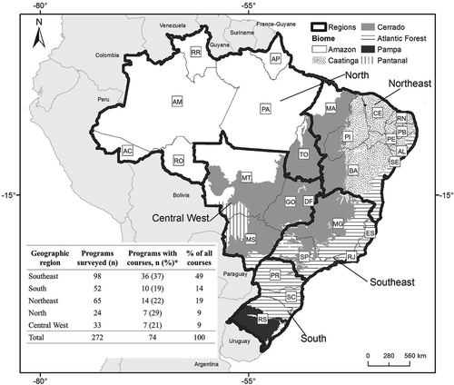

**Figure 1**

Map of Brazil showing different biomes, regions, and state political divisions, as well as postgraduate programs analyzed by geographic region. The symbol * indicates the percentage present within each geographical region. See Table S1 for the entire dataset.

There was a wide variation in the number of ecological restoration courses in each field of study (Tables 1 & S1). Such 27 courses were registered in the field of forestry resources, representing 79% of postgraduate programs in that field and 36% of all ecological restoration courses. In the fields of soil science and botany, the percentage of postgraduate programs with ecological restoration courses was 33 and 27%, respectively; however, these values contribute little to the percentage of courses in all fields, due to the low total number of post-graduated programs. For all other fields of study, the percentage of programs with ecological restoration courses was less than 25% (Table 1). Forestry resources and soil sciences programs, both within the broader field of agricultural sciences, represent 43% of all ecological restoration courses in all fields of study.

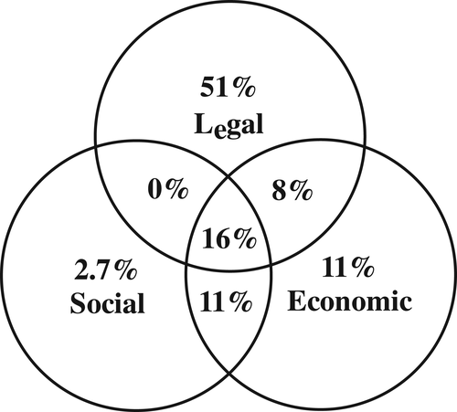

**Figure 2**

The percentage of postgraduate ecological restoration courses in Brazil that include coverage of the legal, social, and economic approaches.

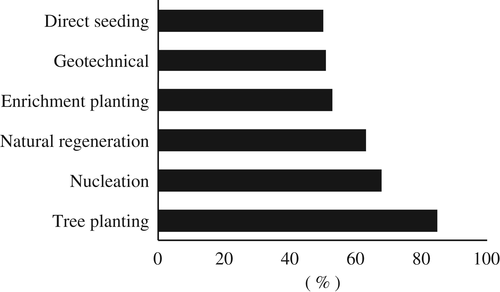

**Figure 3**

The percentage of each ecological restoration technique mentioned in the postgraduate courses in Brazil.

Ordination analysis showed that courses in the same area of concentration are not similar (Fig. 4). This analysis also highlights that variation among courses is mostly associated with ecological restoration techniques (axis 1) and legal aspects and economic approaches (axis 2; Fig. 4).

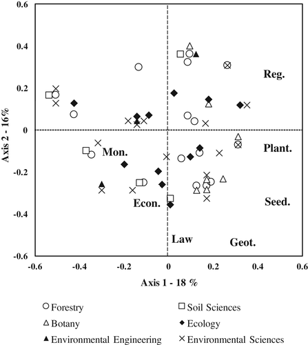

**Figure 4**

PCoA of ecological restoration courses in all fields of study (forestry resources, soil sciences, botany, ecology, environmental engineering, and environmental sciences). The variables shown are the approaches to or techniques of ecological restoration: natural regeneration (Reg.), planting trees (Plant.), direct seeding (Seed.), geological techniques (Geot.), monitoring (Mon.), economic approach (Econ.), and legal approach (Law).

## Discussion

Skilled professionals are one of the most fundamental components of achieving project success in any arena. However, the role of training courses in accomplishing restoration success does not receive wide attention in the scientific community compared to economic, ecological, and technical barriers to restoration success (Manning et al. 2006). Few studies have described the quantity and quality of academic programs, the scope and structure of introductory courses, or professional certification in ecological restoration (e.g. Nelson et al. 2008; Bakker & Howell 2011; Nelson et al. 2017). Considering the ambitious global restoration goals announced (GPFLR 2014), training courses should be taken into account as an indicator of capacity building in restoration. Below, we discuss the results of the postgraduate course analysis and its implications for ecological restoration science and practice, and suggest measures that can be adopted in order to fulfill knowledge gaps and ultimately bring about ecological restoration.

The predominance of courses in the southeast region is related to the number of postgraduate programs offered there (GEOCAPES 2016). Previous studies have also indicated a similar pattern for ecology (Martins et al. 2007) and soil sciences (Ceretta et al. 2008) programs. The high number of courses in the southeast region is desirable, considering the native vegetation deficit in the states of São Paulo and Minas Gerais. However, we found no correlation between the number of courses and native vegetation deficit. This result may be explained by the deficit in the Amazon and Cerrado biomes, predominantly distributed in the north and central west regions, compared with the small number of ecological restoration courses offered in those regions. Therefore, increasing the number of ecological restoration courses in regions with a high native vegetation deficit is an important measure to provide skilled professionals, increase capacity building, and contribute to the success of ecological restoration projects in those regions.

Another aspect worth emphasizing in relation to geographical distribution is the low number of courses in regions covered by the nonforest biomes (*Caatinga*, *Pampas,* and *Pantanal*). These biomes have been neglected in conservation policies and initiatives, and have experienced pronounced habitat loss (see Overbeck et al. 2015). The lack of knowledge concerning methods and approaches for ecological restoration has left these biomes even more vulnerable to environmental degradation (Le Stradic et al. 2014; Andrade et al. 2015). In some cases, this knowledge gap may lead to errors in decision-making (see Lewinsohn et al. 2014), such as the proposal of forest restoration projects in areas originally covered by grassland ecosystems (Veldman et al. 2014). According to Brazilian researchers and practitioners, the restoration of nonforest ecosystems represents a knowledge gap in Brazil (MMA 2015). The regions that have predominantly nonforest ecosystems offer only 20% of the ecological restoration courses in Brazil. Thus, based on the analysis of the geographic distribution of these courses, two priorities emerge: (1) increasing the number of ecological restoration courses offered in areas with a high legal native vegetation deficit, and (2) encouraging the creation of ecological restoration courses for nonforest ecosystems. These proposals aim at increasing knowledge and qualification levels among professionals in planning, implementing, and monitoring restoration projects in the field.

The larger number of courses currently presented within the field of agricultural sciences, especially in forestry resources programs, than in other fields of study may be explained by the history of ecological restoration in Brazil (Rodrigues et al. 2009). During the first phase of ecological restoration in the country (up until 1982; Rodrigues et al. 2009), projects were referred to as “protective plantations,” and their fundamental focus was to guarantee the establishment and development of seedlings through interventions adapted from the forestry industry and agricultural practices (e.g. soil fertilization, control of herbivores, weeding, pruning, etc.). Ecological contributions to restoration were provided later, through research into the classification of ecological groups (Budowski 1965; Swaine & Whitmore 1988) and forest gap dynamics (Denslow 1980). However, it was only from 2000 onwards that the importance of considering ecological processes as indicators of restoration was recognized (Rodrigues et al. 2009). Hence, the basic scientific fields of ecology and botany have potential for contributing to the field of ecological restoration, considering the use of indicators based on ecological processes (Sansevero & Garbin 2015) and the high biodiversity of Brazilian ecosystems (Forzza et al. 2012).

The analysis of the course profiles indicated an absence of any patterns within the main fields of study (forestry resources, ecology, botany, and environmental sciences). This suggests that local, economic, and cultural factors may be more influential than the broad field of study in which a course is offered. The relative lack of courses in some fields (such as soil science and botany) implies a loss of opportunity to discuss specific restoration-related themes within these fields, limiting the generation of complementary knowledge. Another noteworthy result was the lack of programs for masters and PhD degrees in ecological restoration in Brazil. A survey performed by the Society for Ecological Restoration (SER) in June 2016 indicated that there are 63 ecological restoration postgraduate programs in the United States and Canada (SER 2017). Ecological restoration programs should include ecological aspects, as well as social (Turner 2005; Lemgruber et al. 2016), economic (BenDor et al. 2015), cultural (Wortley et al. 2013), and legal aspects (Chaves et al. 2015), in order to consider landscape transformation as well as socioeconomic impacts (Melo et al. 2013; Pinto et al. 2014).

The creation of a postgraduate ecological restoration degree may also be justified by the growing interest in this topic within the academic community, the business environment, and among nongovernmental organizations (Isernhagen et al. 2017). Currently, the Brazilian Network for Ecological Restoration has more than 2,300 members from different sectors of society (Isernhagen et al. 2017). Professional master's degree is a promising model, due to its fundamental objective of filling the gap between scientific theory and practice (Scarano & Oliveira 2005). During the period from 1999 to 2011, there was a significant increase (more than 1,000%) in the number of professional master's degree programs offered, as well as in the number of students registered at this level (from 589 to 12,195; Cirani et al. 2015). However, the significant reduction of investments in education, science, and technology in recent years (Gibney 2015; Angelo 2017) casts uncertainty over the potential to create additional professional master's degree programs.

The small number of courses that cover social and economic approaches reinforces the fact that socioeconomic indicators have been neglected in evaluating the success of ecological restoration projects, as demonstrated by Wortley et al. (2013). Socioeconomic factors must be considered, in order to identify potential impediments and opportunities (see Aronson et al. 2011). To achieve large-scale restoration, it is imperative that the cost per hectare be significantly reduced, by using alternative techniques (Chazdon & Uriarte 2016; Strassburg et al. 2016; Brancalion et al. 2016b) or models with economic benefits (Brancalion et al. 2012). The strong presence of the legal approach in these courses is probably related to the debate concerning the new legislation established by the Native Vegetation Protection Law (Federal Law No. 12,651; Brancalion et al. 2016a). Despite the fundamental role of the legal aspects, it is important to avoid establishing a legalistic scenario of following the law without questioning its technical foundation, or even the possibility of its modification (Durigan et al. 2010). This is another reason why the inclusion of social and economic approaches in these courses, as well as discussion concerning the adequacy of current legislation, is fundamental for good professional training. Professionals capable of recognizing the multiple benefits of ecological restoration and connecting science with policies and legislation are essential for the success of ecological restoration.

The concentration of courses in the southeast region of Brazil (49%) suggests the need for increasing the number of courses in the other regions, based on both the high legal native vegetation deficit and the low level of knowledge concerning ecological restoration of nonforest ecosystems. The predominance of courses in the forestry resources and environmental sciences fields, which together represent 62% of all ecological restoration courses, indicates a need to promote courses in the other fields. This action should facilitate a greater development of topics related to soils, ecology, and botany, reducing the redundancy between courses and favoring complementarity in professional training.

The inclusion of social and economic approaches is highly recommended, due to the impact of ecological restoration projects on human well-being, income generation, and the compromise between conservation and production. Providing academic training in ecological restoration is fundamental for the development of both scientific theory and practice, and represents an essential measure for achieving the ambitious restoration targets, guiding the environmental compliance of rural properties in Brazil, and mitigating the environmental impacts of climate change.

## Citing Literature

[figure not shown]

[Volume26, Issue5](https://onlinelibrary.wiley.com/toc/1526100x/2018/26/5)

September 2018

Pages 997-1004